# imputator

Jisca Huisman

2024-03-30

# Summary

This program imputes (fills in) missing SNP genotype data using a pedigree. Neither the pedigree nor the SNP data is assumed to be error-free.

Each SNP is treated completely independently; for programs that use information from linked SNPs see e.g. Beagle or AlphaImpute.

## Quickstart

- if you are on Windows, you need a linux-emulator, e.g. Cygwin
- you need a Fortran compiler, e.g. gfortran or ifort
- compile the source code into an executable program: `gfortran -O3 sqa_general.f90 sqa_fileIO.f90 imputator.f90 -o imputator`
- create file `pedigree.txt` with columns id - parent1 - parent2. Column names are ignored, unknown parents should be coded as ‘NA’ or ‘0’.
- create a genotype file, e.g. in PLINK .ped/.map format
- run the program: `./imputator --geno <filename>`. For an overview of the options, run `./imputator --help`.

> [!CAUTION] This program is under development and not extensively tested yet. Use is entirely at your own risk.

## Methods overview

The program offers several different imputation methods, which vary in complexity, and therefore in computational speed and accuracy. From simplest to most complex:

### `het`

Set all missing values to heterozygote. Does not require a pedigree.

### `common`

At each SNP, set all missing values to the most common genotype at that SNP. Does not require a pedigree.

### `parents`

Derive the most-likely genotype from the observed parental genotypes. E.g. if both parents are homozygous for the minor allele, the offspring with a missing value will most likely also be homozygous for the minor allele. Ignores non-genotyped parents.

### `ancestors`

As `parents`, with the addition that if e.g. the dam is not genotyped, her probable genotype is derived from the maternal grandparents.

### `full`

The default method, which uses the full pedigree to calculate the most likely genotype for each individual. This includes ancestors, descendants, full siblings, and their mates.

The last method also allows the correction of some genotyping errors, the others do not.

# Method `parent`

The tables show the imputed values for method=‘parents’. The imputed values with methods ‘ancestors’ will often be the same.

Genotypes are coded as 0, 1 or 2 copies of the reference (minor) allele.

### Both parents genotyped

When both parents are genotyped and homozygous, the to be imputed genotype is obvious (ignoring genotyping errors).

When one parent is homozygous and the other heterozygous, there is a 50/50 chance for the offspring to be heterozygous or an identical homozygote. By default, the offspring is always imputed as heterozygous. This can be changed with `--when-in-doubt` to the appropriate homozygote (`hom`) or the most common genotype at the SNP (`com`, which may be the ‘other’ homozygote).

[output not shown]

*: value depends on `--when-in-doubt`, which defaults to `'het'` (heterozygote, 1 allele copy).

### 0 or 1 parent(s) genotyped

When one or both parents are not genotyped at the SNP, the allele(s) are assumed to be a random draw from a population in Hardy-Weinberg Equilibrium. Consequently, genotypes at a SNP with a low minor allele frequency (MAF) are imputed with a higher accuracy.

When one parent is heterozygous and the other parent’s genotype is unknown, the offspring always has a 50% chance to be heterozygous, irrespective of the population allele frequency $q$ ($\frac{1}{2}\times q + \frac{1}{2}\times(1-q)$).

When both parental genotypes are unknown, the greatest uncertainty is when $q=\frac{1}{3}$: then P(heterozygote) = $2\times\frac{1}{3}\times\frac{2}{3} = \frac{4}{9} \approx 0.44$.

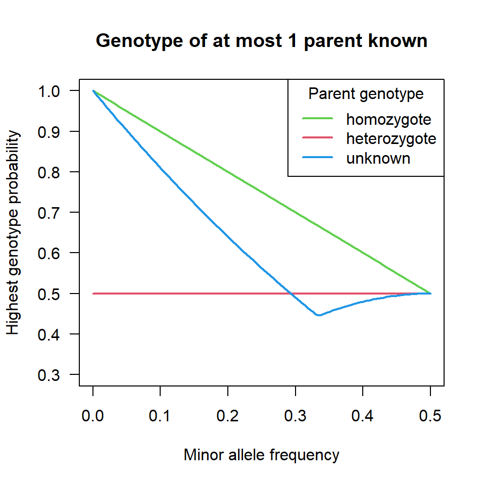

| AF | sire 0 | sire 1 | sire 2 | sire ? | most common |
| --- | --- | --- | --- | --- | --- |
| 0.05 | 0 | 1 | 1 | 0 | 0 |
| 0.1 | 0 | 1 | 1 | 0 | 0 |
| 0.2 | 0 | 1 | 1 | 0 | 0 |
| 0.3 | 0 | 1 | 1 | 0 | 0 |
| 0.35 | 0 | 1 | 1 | 1 | 1 |
| 0.45 | 0 | 1 | 1 | 1 | 1 |
| 0.5 | * | 1 | * | 1 | 1 |
| 0.55 | 1 | 1 | 2 | 1 | 1 |
| 0.75 | 1 | 1 | 2 | 2 | 2 |
| 0.95 | 1 | 1 | 2 | 2 | 2 |

# Method `full`

For each SNP and each individual, the probabilities that there are in truth 0, 1, or 2 copies of the minor allele are estimated using the method described in Kerr & Kinghorn, J. Anim. Breed. Genet., 1996 (https://www.researchgate.net/profile/Richard-Kerr-7/publication/229737009_An_efficient_algorithm_for_segregation_analysis_in_large_populations/links/5a7a2e7c0f7e9b41dbd614f0/An-efficient-algorithm-for-segregation-analysis-in-large-populations.pdf)

This probability depends on an individuals own genotype, the genotypes of its parents and full siblings and their mates (‘anterior probability’), and the genotypes of its offspring and their mates (‘posterior probability’). See `Kerr_Kinghorn_1996_equations_appendix.pdf` for a colour-coded reproduction of the equations in the paper, which corrects a few typesetting errors in the original.

The anterior and posterior probability of each individual depend on those of many others, and can therefore not be calculated all at once. This is especially true in a pedigree with inbreeding loops or other pedigrees where individuals are related via multiple paths.

## Iterative peeling

Instead, first all anterior probabilities are calculated, starting from the pedigree founders and working to the most recent individuals (‘peeling down’). Then posterior probabilities are calculated, starting from the bottom of the pedigree (individuals without offspring) and working towards the top (‘peeling up’). Thirdly and lastly, the genotype probabilities are calculated. These three steps are repeated until all differences between the current genotype probabilities and those calculated in the previous iteration differ less than the value `tol` (default 0.0001, set with `--tol`).

## Imputation

Once the genotype probabilities are calculated, imputation is pretty straight forward: where there is no observed genotype, select the one (from options 0/1/2) with the highest probability. To only impute with high certainty, set a high threshold `--T-impute`; create output that contains no missing values at all, use `--T-impute 0`.

One difficulty is what to do when one parent is homozygous (0 or 2), and the other is heterozygous (1), resulting in an (approximately) 50/50 chance of the individual being homozygous or heterozygous (when there is no genotyped offspring). By default, these are set to heterozygous. This can be changed to the most common genotype at that SNP (`--when-in-doubt com`) or to homozygous (`--when-in-doubt hom`; default is `het`).

## Genotype cleaning

Genotyping errors may negatively affect the imputation accuracy. Some may be detected with high confidence as discrepancies between the anterior and posterior probabilities, and the observed genotype. For example, if both parents are homozygous for the major allele, and all hundred offspring inherited the major allele, but the individual was scored as a heterozygote, this is almost certainly incorrect.

Any such obvious errors are set to missing before the imputation step, using threshold `--T-snpclean` (default: 0.01, i.e. only drop the genotype if its probability is < 0.01). This step can be skipped with `--no-snpclean`.

Not all genotyping errors will be removed: when the genotypes of a parent and offspring are inconsistent, it is not always clear which of the two is incorrect. It is also not always directly clear what the new genotype should be, as the individuals own, incorrect genotype is included in the genotype probabilities (not doing so seems to increase removal of the offspring genotype if the parent is wrong and v.v., but further testing and optimising is needed).

The iterative peeling step is done before the genotype cleaning step, and again between the genotype cleaning step and the imputation step.

## Pedigree cleaning

Errors in the pedigree will also negatively affect the imputation accuracy. For each parent-offspring pair it is checked whether their genotypes across all SNPs are consistent with being parent and offspring, given the genotyping error rate `--err`, or if they are more likely to be otherwise related, or unrelated. For details, see https://github.com/JiscaH/sequoiaExtra/tree/main/pedigree_checker ; parent-parent-offspring trios are tested as two separate parent-offspring pairs.

If the probability to be parent-offspring is less than `--T-pedclean` (default: 0.05), the parent-offspring link is removed from the pedigree. This step can be skipped with `--no-pedclean`.

Note that only genotyped-genotyped parent-offspring pairs are considered. E.g. full sibling pairs where one or both parents are not genotyped are not checked, for this run `sequoia` (https://github.com/JiscaH/sequoia_notR) with only option `--pedigreeIN <filename>`, which is analogous to function `CalcOHLLR()` in the sequoia R package (https://jiscah.github.io/reference/CalcOHLLR.html ).

# Options

### `--T_impute`

It is possible to only impute cases where it is fairly certain what the genotype should be, and leave the rest missing (NA). This can be done with the threshold `T_impute`.

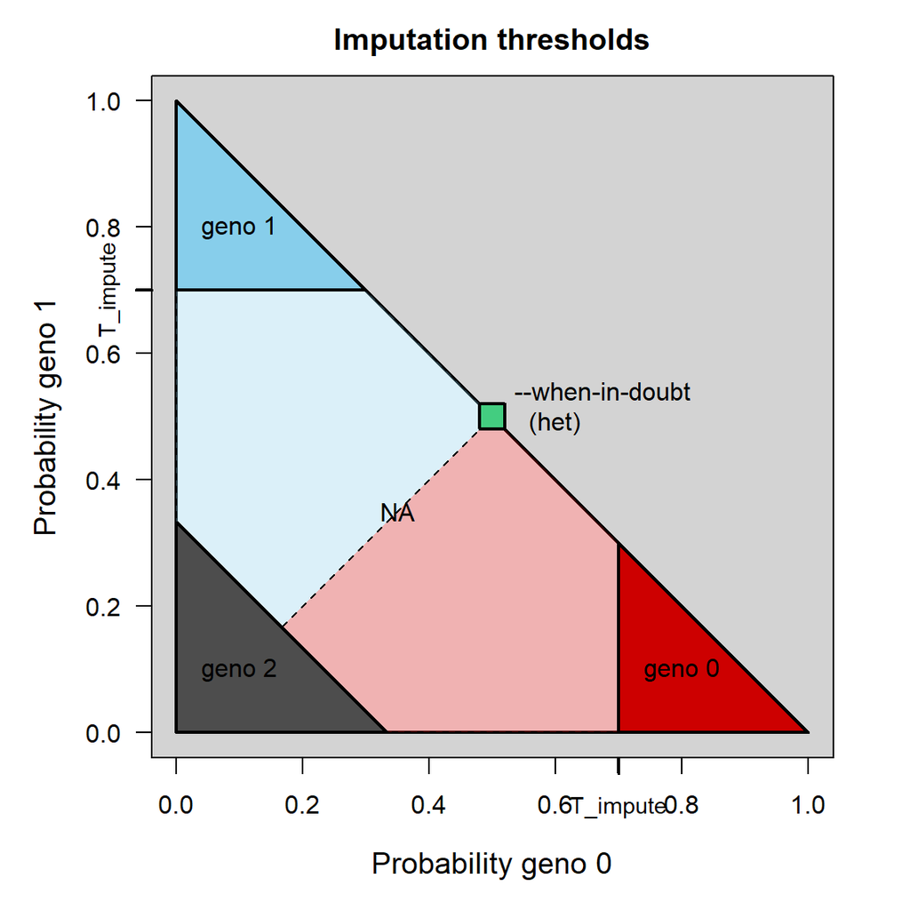

### `--when-in-doubt`

### `--tol`

### `--err`, `--errV`

### `--af`

### `--impute-all`

# Output

## pedclean log

To write.

## snpclean + imputation log

File with a record for each edit made. If a genotype was first set to missing by `snpclean`, and then imputed by `impute`, there will be 2 entries in the log.

Column names are : ‘snp_index’, ‘snp_name’, ‘threshold’, ‘id_index’, ‘id_name’, ‘g_in’, ‘g_out’, ‘prob_0’, ‘prob_1’, ‘prob_2’

here ‘index’ refers to the column number / row number in the genotype file, it is 0 for completely non-genotyped individuals in the pedigree (when `--impute-all`). g_in and g_out are the genotypes in the genotypes in the input and output genotype file, coded as 0/1/2 and -1 for missing values.

The filename for this log can be specified with `--edits-out`. The log can also be turned off with `--no-edits-out`, which gives a slight speed increase - which is neglible with `method=full`, but can be relatively large for the faster methods.

## Genotypes

To write.

# Algorithm details

To write.

# Future additions

## Thresholds

It is hoped to improve performance and make results less depended on fairly arbitrary thresholds by repeating the SNP cleaning - imputation - genotype probabilities steps multiple times, starting from very strict thresholds and gradually loosening them (i.e. similar to simulated annealing). This way, high-confidence imputations may in the next iteration improve detection of genotyping errors and/or further imputation.

## Log input

The log file contains all information to perform the imputation. It may be convenient to first run the algorithm with `--T-impute 0` and `--no-geno-out`, inspect the logfile to decide upon a suitable threshold, and then combine logfile + new threshold + original genotype file into an imputed genotype file, without having to re-do any calculations.

## Estimate genotyping error rate

The genotyping error rate at each SNP can probably be estimated by running the iterative peeling steps many times, for different values of the presumed genotyping error rate `err`. The value resulting in the highest total likelihood of the pedigree + SNP data (sum of genotype probabilities across all individuals) is the most likely value of `err`.